# Lab 3 - Checkpoint 2

Arnaldo Gualberto

27/04/2017

O objetivo do Lab 3 é tentar agrupar dados de filmes utilizando algoritmos de agrupamento. Para essa análise, eu utilizei essa [base de dados](https://www.kaggle.com/deepmatrix/imdb-5000-movie-dataset). Mais detalhes sobre os dados podem ser encontrados na própria página.

# 0. Imports and Settings

```r
library(cluster)
library(dplyr, warn.conflicts=FALSE)
library(GGally)
library(ggplot2)
library(knitr)
library(readr)
library(tibble)
library(tidyverse, warn.conflicts = FALSE)
source('multiplot.R')
```

# 1. Análise Descritiva

Primeiramente, vou carregar os dados que vou utilizar para análise:

```r
dados <- read_csv('data/movie_metadata.csv')
glimpse(dados)
```

```
## Observations: 5,043
## Variables: 28
## $ color                     <chr> "Color", "Color", "Color", "Color", ...
## $ director_name             <chr> "James Cameron", "Gore Verbinski", "...
## $ num_critic_for_reviews    <int> 723, 302, 602, 813, NA, 462, 392, 32...
## $ duration                  <int> 178, 169, 148, 164, NA, 132, 156, 10...
## $ director_facebook_likes   <int> 0, 563, 0, 22000, 131, 475, 0, 15, 0...
## $ actor_3_facebook_likes    <int> 855, 1000, 161, 23000, NA, 530, 4000...
## $ actor_2_name              <chr> "Joel David Moore", "Orlando Bloom",...
## $ actor_1_facebook_likes    <int> 1000, 40000, 11000, 27000, 131, 640,...
## $ gross                     <int> 760505847, 309404152, 200074175, 448...
## $ genres                    <chr> "Action|Adventure|Fantasy|Sci-Fi", "...
## $ actor_1_name              <chr> "CCH Pounder", "Johnny Depp", "Chris...
## $ movie_title               <chr> "Avatar ", "Pirates of the Caribbean...
## $ num_voted_users           <int> 886204, 471220, 275868, 1144337, 8, ...
## $ cast_total_facebook_likes <int> 4834, 48350, 11700, 106759, 143, 187...
## $ actor_3_name              <chr> "Wes Studi", "Jack Davenport", "Step...
## $ facenumber_in_poster      <int> 0, 0, 1, 0, 0, 1, 0, 1, 4, 3, 0, 0, ...
## $ plot_keywords             <chr> "avatar|future|marine|native|paraple...
## $ movie_imdb_link           <chr> "http://www.imdb.com/title/tt0499549...
## $ num_user_for_reviews      <int> 3054, 1238, 994, 2701, NA, 738, 1902...
## $ language                  <chr> "English", "English", "English", "En...
## $ country                   <chr> "USA", "USA", "UK", "USA", NA, "USA"...
## $ content_rating            <chr> "PG-13", "PG-13", "PG-13", "PG-13", ...
## $ budget                    <int> 237000000, 300000000, 245000000, 250...
## $ title_year                <int> 2009, 2007, 2015, 2012, NA, 2012, 20...
## $ actor_2_facebook_likes    <int> 936, 5000, 393, 23000, 12, 632, 1100...
## $ imdb_score                <dbl> 7.9, 7.1, 6.8, 8.5, 7.1, 6.6, 6.2, 7...
## $ aspect_ratio              <dbl> 1.78, 2.35, 2.35, 2.35, NA, 2.35, 2....
## $ movie_facebook_likes      <int> 33000, 0, 85000, 164000, 0, 24000, 0...
```

De acordo com a saída do código R, podemos ver que existem alguns dados faltando. Como são apenas 4, resolvi descartá-los. Também vou analisar somentes os dados dos filmes dos Estados Unidos. Por fim, também vou descartar os filmes com título duplicado e selecionar as colunas que me interessam, são elas:

- **gross**: bilheteria arrecadada pelo filme;
- **budget**: orçamento gasto para produção do filme;
- **imdb_score**: avaliação média dos usuários do IMBD;
- **duration**: duração do filme (em minutos);
- **movie_facebook_likes**: quantidade de likes do filme na página do facebook;
- **actor_1_facebook_likes**: quantidade de likes do ator no facebook;

Além dessas colunas, também resolvi extrair outras que podem ser interessantes na análise final do agrupamento, são elas:

- **movie_title**: representa o título do filme;
- **actor_1_name**: nome do ator principal;

```r
dados_usa = dados %>%
  filter(!duplicated(dados$movie_title)) %>%
  filter(country == 'USA') %>%
  filter(complete.cases(.)) %>%
  select(filme = movie_title, ator = actor_1_name, bilheteria = gross, orcamento = budget, duracao = duration, avaliacao = imdb_score, likes_filme = movie_facebook_likes, likes_ator = actor_1_facebook_likes)

head(dados_usa) %>% kable()
```

| filme | ator | bilheteria | orcamento | duracao | avaliacao | likes_filme | likes_ator |
| --- | --- | --- | --- | --- | --- | --- | --- |
| Avatar | CCH Pounder | 760505847 | 237000000 | 178 | 7.9 | 33000 | 1000 |
| Pirates of the Caribbean: At World’s End | Johnny Depp | 309404152 | 300000000 | 169 | 7.1 | 0 | 40000 |
| The Dark Knight Rises | Tom Hardy | 448130642 | 250000000 | 164 | 8.5 | 164000 | 27000 |
| John Carter | Daryl Sabara | 73058679 | 263700000 | 132 | 6.6 | 24000 | 640 |
| Spider-Man 3 | J.K. Simmons | 336530303 | 258000000 | 156 | 6.2 | 0 | 24000 |
| Tangled | Brad Garrett | 200807262 | 260000000 | 100 | 7.8 | 29000 | 799 |

Ao todo, após as filtragens, temos dados sobre **2097 filmes dos Estados Unidos**.

Vou iniciar a análise descritiva analisando a sumarização dos dados:

```r
dados_usa %>%
  select(-filme, -ator) %>%
  summary() %>%
  kable()
```

|  | bilheteria | orcamento | duracao | avaliacao | likes_filme | likes_ator |
| --- | --- | --- | --- | --- | --- | --- |
|  | Min. : 703 | Min. : 218 | Min. : 37.0 | Min. :1.600 | Min. : 0 | Min. : 0.0 |
|  | 1st Qu.: 12385519 | 1st Qu.: 11000000 | 1st Qu.: 95.0 | 1st Qu.:5.800 | 1st Qu.: 0 | 1st Qu.: 814.5 |
|  | Median : 34746109 | Median : 26000000 | Median :105.0 | Median :6.500 | Median : 246 | Median : 2000.0 |
|  | Mean : 57982988 | Mean : 40390571 | Mean :109.7 | Mean :6.389 | Mean : 9283 | Mean : 8253.5 |
|  | 3rd Qu.: 75450798 | 3rd Qu.: 55000000 | 3rd Qu.:119.0 | 3rd Qu.:7.100 | 3rd Qu.: 11000 | 3rd Qu.: 13000.0 |
|  | Max. :760505847 | Max. :300000000 | Max. :330.0 | Max. :9.300 | Max. :349000 | Max. :640000.0 |

Pode-se perceber que *avaliação* e *duração* do filme são as variáveis com menor range, ou seja, que menos variam em comparação com as outras variáveis. *Bilheteria* e *orçamento* apresentam enormes variações, com valores máximo e mínimo bem distante das média e mediana. Logo, mais para frente, deveremos tratar esses valores para que o agrupamento não seja totalmente influenciado por essas variáveis.

Também quero saber o desvio-padrão de cada variável utilizada:

```r
dados_usa %>% summarise(sd(bilheteria), sd(orcamento), sd(avaliacao), sd(duracao), sd(likes_ator), sd(likes_filme)) %>%
  kable()
```

| sd(bilheteria) | sd(orcamento) | sd(avaliacao) | sd(duracao) | sd(likes_ator) | sd(likes_filme) |
| --- | --- | --- | --- | --- | --- |
| 72287659 | 43228335 | 1.053828 | 22.30267 | 16907.56 | 21802.75 |

É importante saber o desvio-padrão de cada variável quando eu for normalizar os valores aplicando a *padronização*. Ex.: sabendo que a variável *bilheteria* apresenta $\mu \approx$ 58 milhões e $\sigma \approx$ 72 milhões, filmes que arrecadaram 200 milhões de dólares em bilheteria estão a aproximadamente dois desvios-padrões da média ($\approx \mu + 2\sigma$).

A título de curiosidade, quero saber quais são os filmes cujo cada variável que eu escolhi para análise apresenta seu valor máximo:

```r
dados_usa %>%
  filter(likes_ator == max(likes_ator)) %>%
  kable()
```

| filme | ator | bilheteria | orcamento | duracao | avaliacao | likes_filme | likes_ator |
| --- | --- | --- | --- | --- | --- | --- | --- |
| Anchorman: The Legend of Ron Burgundy | Darcy Donavan | 84136909 | 2.6e+07 | 98 | 7.2 | 0 | 640000 |

```r
dados_usa %>%
  filter(likes_filme == max(likes_filme)) %>%
  kable()
```

| filme | ator | bilheteria | orcamento | duracao | avaliacao | likes_filme | likes_ator |
| --- | --- | --- | --- | --- | --- | --- | --- |
| Interstellar | Matthew McConaughey | 187991439 | 1.65e+08 | 169 | 8.6 | 349000 | 11000 |

```r
dados_usa %>%
  filter(bilheteria == max(bilheteria)) %>%
  kable()
```

| filme | ator | bilheteria | orcamento | duracao | avaliacao | likes_filme | likes_ator |
| --- | --- | --- | --- | --- | --- | --- | --- |
| Avatar | CCH Pounder | 760505847 | 2.37e+08 | 178 | 7.9 | 33000 | 1000 |

```r
dados_usa %>%
  filter(orcamento == max(orcamento)) %>%
  kable()
```

| filme | ator | bilheteria | orcamento | duracao | avaliacao | likes_filme | likes_ator |
| --- | --- | --- | --- | --- | --- | --- | --- |
| Pirates of the Caribbean: At World’s End | Johnny Depp | 309404152 | 3e+08 | 169 | 7.1 | 0 | 40000 |

```r
dados_usa %>%
  filter(avaliacao == max(avaliacao)) %>%
  kable()
```

| filme | ator | bilheteria | orcamento | duracao | avaliacao | likes_filme | likes_ator |
| --- | --- | --- | --- | --- | --- | --- | --- |
| The Shawshank Redemption | Morgan Freeman | 28341469 | 2.5e+07 | 142 | 9.3 | 108000 | 11000 |

```r
dados_usa %>%
  filter(duracao == max(duracao)) %>%
  kable()
```

| filme | ator | bilheteria | orcamento | duracao | avaliacao | likes_filme | likes_ator |
| --- | --- | --- | --- | --- | --- | --- | --- |
| Blood In, Blood Out | Delroy Lindo | 4496583 | 3.5e+07 | 330 | 8 | 6000 | 848 |

Podemos perceber que **Avatar** é o filme que mais arrecadou bilheteria nos EUA, enquanto **Piratas do Caribe: o fim do mundo** foi o filme que mais gastou-se para ser produzido. Além disso, o filme mais bem avaliado pelos usuários do IMDB é **The Shawshank Redemption** (em português, *Um sonho de liberdade*). Pelos dados do facebook utilizados, o filme **Interstellar** e a atriz **Darcy Donavam** são o filme e a atriz com mais curtidas, respectivamente. Finalmente, **Blood In, Blood Out** é o longa-metragem mais longo dos EUA, com aproximadamente 5h30min de duração.

Quero analisar agora a distribuição de cada variável individualmente e em pares. Para isso, vou utilzar *ggpairs* do módulo *GGally*:

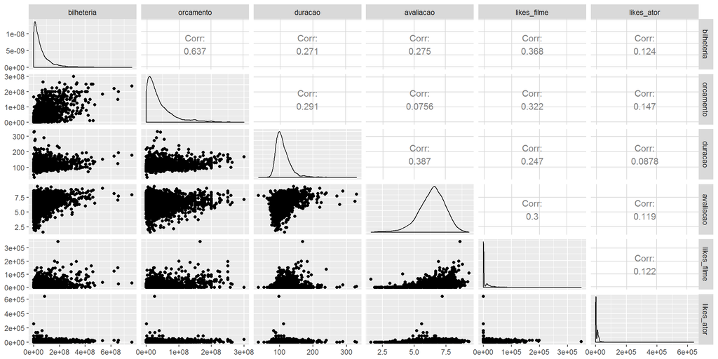

```r
dados_usa %>%
  select(-filme, -ator) %>%
  GGally::ggpairs()
```

Pelo gráfico acima, ao analisar as distribuições de cada variável (diagona principal), podemos perceber que quase todas apresentam uma concentração à esquerda com cauda longa à direita, exceto a variável *avaliação*.

Também podemos observar que praticamente todas as variáveis utilizadas apresentam pouca correlação entre si. De fato, apenas *orçamento* e *bilheteria*, apresentam um correlação mais forte (0.637). Isso indica, de certa forma, que quanto mais se gasta para produzir um filme, maior é o retorno na bilheteria.

Para finalizar minha análise descritiva, quero observar a distribuição dos 2097 filmes de acordo com cada variável:

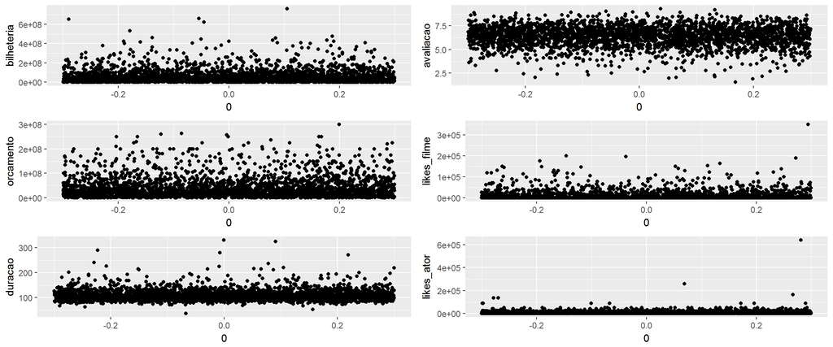

```r
plot_bil <- dados_usa %>%
  ggplot(aes(x = 0, y = bilheteria)) +
  geom_point(position = position_jitter(width=0.3))

plot_orc <- dados_usa %>%
  ggplot(aes(x = 0, y = orcamento)) +
  geom_point(position = position_jitter(width=0.3))

plot_dur <- dados_usa %>%
  ggplot(aes(x = 0, y = duracao)) +
  geom_point(position = position_jitter(width=0.3))

plot_ava <- dados_usa %>%
  ggplot(aes(x = 0, y = avaliacao)) +
  geom_point(position = position_jitter(width=0.3))

plot_lf <- dados_usa %>%
  ggplot(aes(x = 0, y = likes_filme)) +
  geom_point(position = position_jitter(width=0.3))

plot_la <- dados_usa %>%
  ggplot(aes(x = 0, y = likes_ator)) +
  geom_point(position = position_jitter(width=0.3))

multiplot(plot_bil, plot_orc, plot_dur, plot_ava, plot_lf, plot_la,  cols = 2)
```

Os gráficos acima apresentam pontos interessantes:

- Os dados de *bilheteria*, *orçamento*, *likes_ator* e *likes_filme* se concentram, em sua maioria, na base do gráfico;
- Em geral, a média de *duração* dos filmes é aproximadamente 100 minutos (como verificado na sumarização dos dados);
- Os dados de *avaliação* são visualmente os mais dispersos, variando disformemente por todo o gráfico, mas com uma concentração maior entre 5,0 e 7,5.

Pela distribuição dos dados acima, eu arriscaria dizer que existem de 2 a, no máximo, 4 grupos de filmes diferentes. Vamos verificar isso na próxima seção.

# 2. Clusterização

Agora vou dar início ao agrupamento (clusterização) dos dados. Antes de mais nada, vou efetuar a **padronização** dos dados:

```r
filmes = dados_usa %>%
  select(-filme, -ator) %>%
  mutate(bilheteria = scale(bilheteria),
           orcamento = scale(orcamento),
           duracao = scale(duracao),
           likes_filme = scale(likes_filme),
           likes_ator = scale(likes_ator),
           avaliacao = scale(avaliacao))
```

## 2.1 Clusterização Hierárquica

O primeiro algoritmo de clusterização que vou utilizar é a **clusterização hierárquica**. Empiricamente, escolhi o método **ward.D** e a **distância de Manhattan**. Além disso, defini clusterizar os dados em **3 grupos diferentes**, pois vi que essa combinação de parâmetros geraram grupos melhores.

**Observação**: testei diversas combinações de métodos de distância e de clusterização. Além disso, também normalizeis os dados de maneiras diferentes (padronização e normalização entre [0-1]). Os valores escolhidos foram os que geraram os melhores grupos, ao meu ver. Em muitas combinações houveram grupos com poucos filmes, o que não achei interessante.

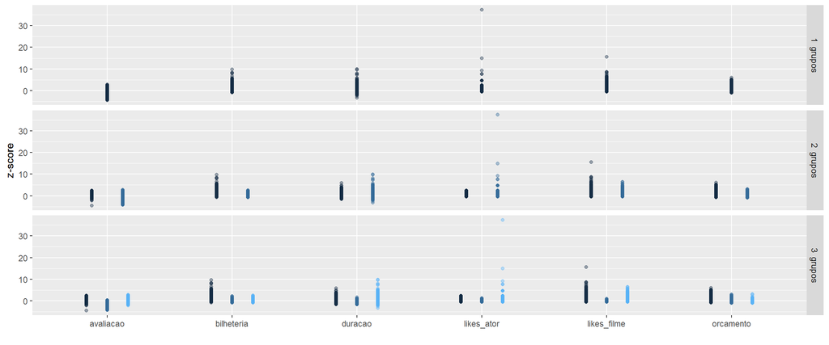

```r
agrupamento_hs <- filmes %>%
  dist(method = "manhattan") %>%
  hclust(method = "ward.D")

# Retomando os valores do título do filme e ator_principal para que apareçam na tabela atribuições
filmes <- dados_usa %>%
  mutate(bilheteria = scale(bilheteria),
           orcamento = scale(orcamento),
           duracao = scale(duracao),
           likes_filme = scale(likes_filme),
           likes_ator = scale(likes_ator),
           avaliacao = scale(avaliacao))

atribuicoes <- tibble(k = 1:3) %>%
  group_by(k) %>%
  do(cbind(filmes, grupo = cutree(agrupamento_hs, .$k)))

atribuicoes_long = atribuicoes %>%
  select(-filme, -ator) %>%
  gather(key = "variavel", value = "valor", -k, -grupo)

atribuicoes_long %>%
  ggplot(aes(x = variavel, y = valor, group = grupo, colour = grupo)) +
  geom_point(alpha = .4, position = position_dodge(width = .5)) +
  facet_grid(paste(k, " grupos" )~ .) +
  labs(x = "", y = "z-score") +
  theme(legend.position = "none")
```

Também podemos visualizar o gráfico acima com coordenadas paralelas. É importante notar, entretanto, que as variáveis (eixo x) estão distribuidas diferentemente nos gráficos com pontos e coordenadas paralelas.

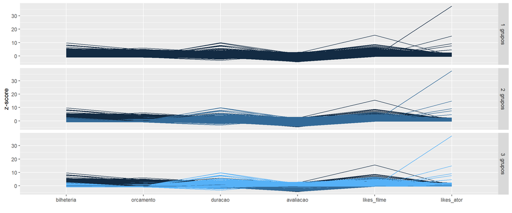

```r
atribuicoes %>%
  ggparcoord(columns = c(4:9), groupColumn="grupo") +
  facet_grid(paste(k, " grupos" )~ .) +
  labs(x = "", y = "z-score") +
  theme(legend.position = "none")
```

Separando os 3 grupos em gráficos diferentes, temos:

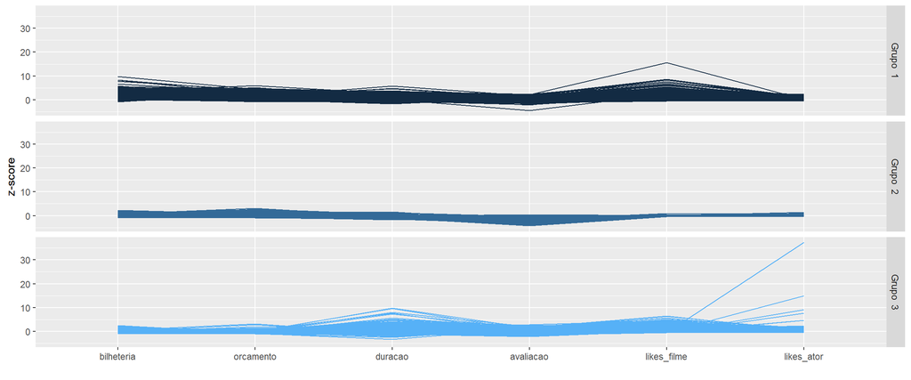

```r
atribuicoes %>%
  filter(k == 3) %>%
  ggparcoord(columns = c(4:9), groupColumn="grupo") +
  facet_grid(paste("Grupo ", grupo)~ .) +
  labs(x = "", y = "z-score") +
  theme(legend.position = "none")
```

Pelos gráficos, acredito que podemos diferenciar os 3 grupos da seguinte forma:

**Grupo 1**: *Marketeiros*  
Filmes de altíssima bilheteria, alto orçamento, longa duração, boa avaliação em geral, muitas curtidas no facebook e atores renomados.

**Grupo 3**: *Para todos os gostos*  
Filmes de boa bilheteria e orçamento, curta-e-longa duração, boa avaliação, muitas curtidas no facebook e atores renomados.

Vamos agora ver alguns dos filmes de cada grupo:

```r
filmes_hclust <- atribuicoes %>%
  filter(k == 3) %>%
  left_join(dados_usa, by=c("filme")) %>%
  select(k, filme, ator.y, bilheteria.y, orcamento.y, duracao.y, likes_filme.y, likes_ator.y, avaliacao.y, grupo)

filmes_hclust %>%
  filter(grupo == 1) %>%
  top_n(10, bilheteria.y) %>%
  kable()
```

| k | filme | ator.y | bilheteria.y | orcamento.y | duracao.y | likes_filme.y | likes_ator.y | avaliacao.y | grupo |
| --- | --- | --- | --- | --- | --- | --- | --- | --- | --- |
| 3 | Avatar | CCH Pounder | 760505847 | 2.37e+08 | 178 | 33000 | 1000 | 7.9 | 1 |
| 3 | The Dark Knight Rises | Tom Hardy | 448130642 | 2.50e+08 | 164 | 164000 | 27000 | 8.5 | 1 |
| 3 | Avengers: Age of Ultron | Chris Hemsworth | 458991599 | 2.50e+08 | 141 | 118000 | 26000 | 7.5 | 1 |
| 3 | The Avengers | Chris Hemsworth | 623279547 | 2.20e+08 | 173 | 123000 | 26000 | 8.1 | 1 |
| 3 | Titanic | Leonardo DiCaprio | 658672302 | 2.00e+08 | 194 | 26000 | 29000 | 7.7 | 1 |
| 3 | Jurassic World | Bryce Dallas Howard | 652177271 | 1.50e+08 | 124 | 150000 | 3000 | 7.0 | 1 |
| 3 | The Dark Knight | Christian Bale | 533316061 | 1.85e+08 | 152 | 37000 | 23000 | 9.0 | 1 |
| 3 | Star Wars: Episode I - The Phantom Menace | Natalie Portman | 474544677 | 1.15e+08 | 136 | 13000 | 20000 | 6.5 | 1 |
| 3 | Shrek 2 | Rupert Everett | 436471036 | 1.50e+08 | 93 | 0 | 692 | 7.2 | 1 |
| 3 | Star Wars: Episode IV - A New Hope | Harrison Ford | 460935665 | 1.10e+07 | 125 | 33000 | 11000 | 8.7 | 1 |

```r
filmes_hclust %>%
  filter(grupo == 2) %>%
  head(10) %>%
  kable()
```

| k | filme | ator.y | bilheteria.y | orcamento.y | duracao.y | likes_filme.y | likes_ator.y | avaliacao.y | grupo |
| --- | --- | --- | --- | --- | --- | --- | --- | --- | --- |
| 3 | Wild Wild West | Will Smith | 113745408 | 1.70e+08 | 106 | 0 | 10000 | 4.8 | 2 |
| 3 | The Mummy: Tomb of the Dragon Emperor | Jet Li | 102176165 | 1.45e+08 | 112 | 0 | 5000 | 5.2 | 2 |
| 3 | The Last Airbender | Seychelle Gabriel | 131564731 | 1.50e+08 | 103 | 18000 | 1000 | 4.2 | 2 |
| 3 | Mars Needs Moms | Elisabeth Harnois | 21379315 | 1.50e+08 | 88 | 0 | 921 | 5.4 | 2 |
| 3 | Fun with Dick and Jane | John Michael Higgins | 110332737 | 1.00e+08 | 90 | 2000 | 957 | 6.1 | 2 |
| 3 | Stealth | Sam Shepard | 31704416 | 1.35e+08 | 121 | 0 | 820 | 5.0 | 2 |
| 3 | Rio 2 | Miguel Ferrer | 131536019 | 1.03e+08 | 101 | 0 | 688 | 6.4 | 2 |
| 3 | The 13th Warrior | Tony Curran | 32694788 | 8.50e+07 | 102 | 0 | 845 | 6.6 | 2 |
| 3 | Batman & Robin | Michael Gough | 107285004 | 1.25e+08 | 125 | 0 | 920 | 3.7 | 2 |
| 3 | Charlie’s Angels: Full Throttle | Demi Moore | 100685880 | 1.20e+08 | 107 | 0 | 2000 | 4.8 | 2 |

```r
filmes_hclust %>%
  filter(grupo == 3) %>%
  top_n(10, duracao.y) %>%
  kable()
```

| k | filme | ator.y | bilheteria.y | orcamento.y | duracao.y | likes_filme.y | likes_ator.y | avaliacao.y | grupo |
| --- | --- | --- | --- | --- | --- | --- | --- | --- | --- |
| 3 | Gods and Generals | Billy Campbell | 12870569 | 56000000 | 280 | 953 | 789 | 6.3 | 3 |
| 3 | All the Pretty Horses | Matt Damon | 15527125 | 57000000 | 220 | 652 | 13000 | 5.8 | 3 |
| 3 | Heaven’s Gate | Jeff Bridges | 1500000 | 44000000 | 325 | 1000 | 12000 | 6.8 | 3 |
| 3 | Blood In, Blood Out | Delroy Lindo | 4496583 | 35000000 | 330 | 6000 | 848 | 8.0 | 3 |
| 3 | Apocalypse Now | Harrison Ford | 78800000 | 31500000 | 289 | 19000 | 11000 | 8.5 | 3 |
| 3 | Gettysburg | Tom Berenger | 10769960 | 25000000 | 271 | 0 | 854 | 7.7 | 3 |
| 3 | The Greatest Story Ever Told | Martin Landau | 8000000 | 20000000 | 225 | 1000 | 940 | 6.6 | 3 |
| 3 | Dances with Wolves | Mary McDonnell | 184208848 | 22000000 | 236 | 0 | 933 | 8.0 | 3 |
| 3 | The Godfather: Part II | Robert De Niro | 57300000 | 13000000 | 220 | 14000 | 22000 | 9.0 | 3 |
| 3 | Gone with the Wind | Hattie McDaniel | 198655278 | 3977000 | 226 | 16000 | 503 | 8.2 | 3 |

Ao meu ver, os filmes apresentados se encaixam bem nos grupos descritos.

# 2.2 K-Means

Vamos agora utilizar o algoritmo **K-Means**. Resolvi também utilizar 3 grupos para poder comparar os dois algoritmos.

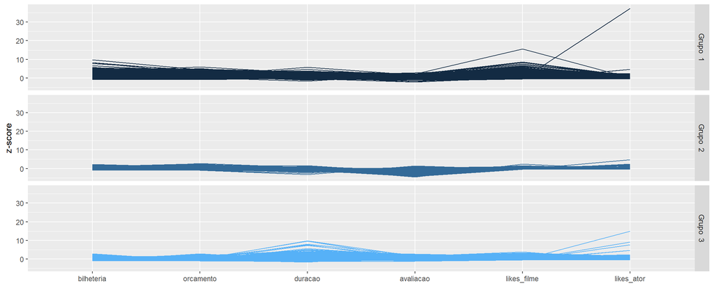

```r
filmes <- dados_usa

atribuicoes <- tibble(k = 1:3) %>%
  group_by(k) %>%
  do(cbind(filmes, grupo = cutree(agrupamento_hs, .$k)))

km <- filmes %>%
  select(-filme, -ator) %>%
  mutate(bilheteria = scale(bilheteria),
           orcamento = scale(orcamento),
           duracao = scale(duracao),
           likes_filme = scale(likes_filme),
           likes_ator = scale(likes_ator),
           avaliacao = scale(avaliacao)) %>%
  kmeans(centers = 3, nstart=20)

filmes$kmcluster = km$cluster

filmes %>%
  ggparcoord(columns = c(3:8), groupColumn="kmcluster") +
  facet_grid(paste("Grupo ", kmcluster) ~ .) +
  labs(x = "", y = "z-score") +
  theme(legend.position = "none")
```

**Grupo 1**: *Para todos os gostos*  
Filmes de boa bilheteria e orçamento, **longa duração**, boa avaliação, muitas curtidas no facebook e atores renomados.

**Grupo 3**: *Fracassados*  
Filmes com maior orçamento que bilheteria, **curta-e-longa duração**, avaliação ruim, poucas curtidas no facebook e atores renomados ou pouco conhecidos.

**Observação 1**: as variáveis destacadas em negrito representam as mudanças em relação ao grupo de mesmo nome dado pelo algoritmo de clusterização hierárquica (ver seção 2.1).

**Observação 2**: a ordem dos grupos citados acima pode ser diferentes dos gráficos, pois todas vez que o código R é executado a clusterização pode gerar resultados diferentes.

Vamos agora observar alguns filmes de cada um dos grupos:

```r
filmes %>%
  filter(kmcluster == 1) %>%
  top_n(10, avaliacao) %>%
  kable()
```

| filme | ator | bilheteria | orcamento | duracao | avaliacao | likes_filme | likes_ator | kmcluster |
| --- | --- | --- | --- | --- | --- | --- | --- | --- |
| The Dark Knight | Christian Bale | 533316061 | 1.85e+08 | 152 | 9.0 | 37000 | 23000 | 1 |
| Interstellar | Matthew McConaughey | 187991439 | 1.65e+08 | 169 | 8.6 | 349000 | 11000 | 1 |
| Inception | Leonardo DiCaprio | 292568851 | 1.60e+08 | 148 | 8.8 | 175000 | 29000 | 1 |
| The Lord of the Rings: The Return of the King | Orlando Bloom | 377019252 | 9.40e+07 | 192 | 8.9 | 16000 | 5000 | 1 |
| The Lord of the Rings: The Two Towers | Christopher Lee | 340478898 | 9.40e+07 | 172 | 8.7 | 10000 | 16000 | 1 |
| Saving Private Ryan | Tom Hanks | 216119491 | 7.00e+07 | 169 | 8.6 | 22000 | 15000 | 1 |
| The Matrix | Keanu Reeves | 171383253 | 6.30e+07 | 136 | 8.7 | 25000 | 18000 | 1 |
| Forrest Gump | Tom Hanks | 329691196 | 5.50e+07 | 142 | 8.8 | 59000 | 15000 | 1 |
| The Shawshank Redemption | Morgan Freeman | 28341469 | 2.50e+07 | 142 | 9.3 | 108000 | 11000 | 1 |
| Star Wars: Episode V - The Empire Strikes Back | Harrison Ford | 290158751 | 1.80e+07 | 127 | 8.8 | 17000 | 11000 | 1 |
| Star Wars: Episode IV - A New Hope | Harrison Ford | 460935665 | 1.10e+07 | 125 | 8.7 | 33000 | 11000 | 1 |

```r
filmes %>%
  filter(kmcluster == 2) %>%
  top_n(10, bilheteria) %>%
  kable()
```

| filme | ator | bilheteria | orcamento | duracao | avaliacao | likes_filme | likes_ator | kmcluster |
| --- | --- | --- | --- | --- | --- | --- | --- | --- |
| Jurassic Park III | Michael Jeter | 181166115 | 93000000 | 92 | 5.9 | 0 | 693 | 2 |
| Shark Tale | Robert De Niro | 160762022 | 75000000 | 90 | 6.0 | 0 | 22000 | 2 |
| The SpongeBob Movie: Sponge Out of Water | Tim Conway | 162495848 | 74000000 | 92 | 6.0 | 16000 | 870 | 2 |
| Alvin and the Chipmunks: The Squeakquel | Amy Poehler | 219613391 | 75000000 | 88 | 4.5 | 2000 | 1000 | 2 |
| Austin Powers in Goldmember | Verne Troyer | 213079163 | 63000000 | 94 | 6.2 | 0 | 645 | 2 |
| Alvin and the Chipmunks | Jesse McCartney | 217326336 | 60000000 | 92 | 5.2 | 0 | 1000 | 2 |
| Liar Liar | Maura Tierney | 181395380 | 45000000 | 86 | 6.8 | 0 | 509 | 2 |
| Big Daddy | Steve Buscemi | 163479795 | 34200000 | 93 | 6.4 | 0 | 12000 | 2 |
| The Waterboy | Adam Sandler | 161487252 | 20000000 | 90 | 6.1 | 0 | 11000 | 2 |
| 3 Men and a Baby | Tom Selleck | 167780960 | 11000000 | 102 | 5.9 | 3000 | 19000 | 2 |

```r
filmes %>%
  filter(kmcluster == 3) %>%
  head(10) %>%
  kable()
```

| filme | ator | bilheteria | orcamento | duracao | avaliacao | likes_filme | likes_ator | kmcluster |
| --- | --- | --- | --- | --- | --- | --- | --- | --- |
| The Polar Express | Tom Hanks | 665426 | 1.65e+08 | 100 | 6.6 | 10000 | 15000 | 3 |
| The Fast and the Furious | Paul Walker | 144512310 | 3.80e+07 | 106 | 6.7 | 14000 | 23000 | 3 |
| The Wolfman | Anthony Hopkins | 61937495 | 1.50e+08 | 119 | 5.8 | 0 | 12000 | 3 |
| Final Fantasy: The Spirits Within | Steve Buscemi | 32131830 | 1.37e+08 | 106 | 6.4 | 0 | 12000 | 3 |
| Rio 2 | Miguel Ferrer | 131536019 | 1.03e+08 | 101 | 6.4 | 0 | 688 | 3 |
| Total Recall | Ronny Cox | 119412921 | 6.50e+07 | 113 | 7.5 | 0 | 605 | 3 |
| The Chronicles of Riddick | Vin Diesel | 57637485 | 1.05e+08 | 134 | 6.7 | 0 | 14000 | 3 |
| Speed Racer | Scott Porter | 43929341 | 1.20e+08 | 135 | 6.1 | 0 | 690 | 3 |
| Knight and Day | Tom Cruise | 76418654 | 1.17e+08 | 117 | 6.3 | 11000 | 10000 | 3 |
| Windtalkers | Nicolas Cage | 40911830 | 1.15e+08 | 153 | 6.0 | 0 | 12000 | 3 |

# 3. Conclusões

Este relatório realizou o agrupamento de dados de filmes em 3 grupos utilizando métodos de agrupamento diferentes: **clusterização hierárquica** e **K-Means**.

De acordo com os resultados, podemos concluir que: